# Practical Session 3 Momentum - NAG Alaa

## Practical Work 3

For this practical work, the student will have to develop a Python program that is able to implement the accelerated gradient descent methods **(Momentum and NAG)** in order to achieve the linear regression of a set of datapoints.

#### Import numpy, matplotlib.pyplot and make it inline

```python
import numpy as np
import matplotlib.pyplot as plt
import pandas as pd
from sklearn.metrics import r2_score
```

```python
x = np.linspace(0,20)
y=-2*x+1


dict={'x0':1,'x1':x , 'y':y}

df=pd.DataFrame(dict)
df = df.sample(frac=1)


col=df.shape[1]
x=np.array(df.iloc[:,1:col-1])
y=np.array(df.iloc[:,col-1:col])

theta0=0
theta1=0
```

```python
print(" x = \n",x)
print(" y = \n",y)
```

```
 x =
 [[17.55102041]
 [15.91836735]
 [11.83673469]
 [11.02040816]
 [ 8.16326531]
 [ 1.2244898 ]
 [19.18367347]
 [ 4.48979592]
 [ 3.67346939]
 [18.7755102 ]
 [14.28571429]
 [13.87755102]
 [ 9.3877551 ]
 [ 9.79591837]
 [12.24489796]
 [ 2.44897959]
 [ 2.85714286]
 [ 4.08163265]
 [ 8.97959184]
 [ 7.34693878]
 [20.        ]
 [ 5.71428571]
 [ 3.26530612]
 [15.51020408]
 [ 4.89795918]
 [11.42857143]
 [ 6.12244898]
 [ 5.30612245]
 [ 0.        ]
 [ 0.40816327]
 [15.10204082]
 [17.14285714]
 [10.20408163]
 [19.59183673]
 [ 2.04081633]
 [14.69387755]
 [ 0.81632653]
 [13.06122449]
 [ 1.63265306]
```

[output cut: 47 more lines]

```
 [-28.3877551 ]
 [ -0.63265306]
 [-25.12244898]
 [ -2.26530612]
 [-20.2244898 ]
 [-25.93877551]
 [-35.73469388]
 [-34.91836735]
 [-12.87755102]
 [-32.46938776]
 [-12.06122449]
 [-24.30612245]
 [-16.14285714]
 [-31.65306122]
 [-14.51020408]]
```

#### Plot your data points.

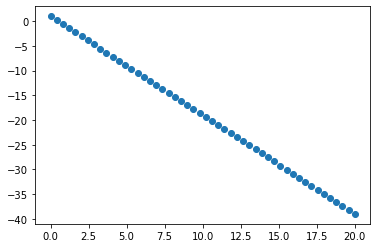

```python
plt.scatter(df.x1,df.y)
```

#### Use your final version of the implemented Batch GD algorithm for single variable to find the best line filt of the given data.

#### Coose the suitable number of iterations, learning rate, and stop criteria.

#### Calculate r2 score. Shouldn't below 0.9

#### Plot the required curves (loss-epochs, loss-theta0, loss-theta1, all fitted lines per epoch (single graph) , best fit line)

```python
alpha=0.001
itera=100
gama=0.6
```

```python
def momentum_GD(x,y,alpha,epochs,gama):
    theta_0=[]
    theta_1=[]
    ress=[]
    theta0=0
    theta1=0
    hyp=[]
    v0=0
    v1=0
    v_0=[]
    v_1=[]

    for i in range(epochs):
        h=theta0+theta1*x
        hyp.append(h)
        error = sum((h-y)**2)
        res = error/ (2 * len(x))
        ress.append(res)
        a = sum(h-y) / ( len(x))
        b = sum((h-y)*x) / ( len(x))

        v0=gama*v0+ (alpha*a)
        v_0.append(v0)
        theta0 = theta0 - v0
        theta_0.append(theta0)
        v1=gama*v1+ (alpha*b)
        theta1 = theta1 - v1
        theta_1.append(theta1)
        v_1.append(v1)
        if i>0 and abs(ress[-1]-ress[-2])< 0.001 :
            break
    dict1={"theta_0":theta0,"theta_1":theta1,"losses":ress,"hypothesis output":hyp,"optimum theta_0":theta_0,"optimum theta_1":theta_1}
    return dict1
```

```python
dict2= momentum_GD(x,y,0.001,100,.06)
```

```python
dict2["theta_0"]
```

```
array([-0.13033104])
```

```python
h=theta0+theta1*x
```

```python
#dict2["hypothesis output"][-1][:,1:2]
```

```python
from sklearn.metrics import r2_score
r2_score(y, dict2["hypothesis output"][-1] )
```

```
0.9975935651453174
```

```python
loss=np.array(dict2['losses'])
#loss[:,0:1]
#loss
```

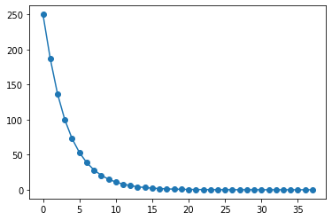

```python
#loss=np.array(dict2['losses'])
plt.plot(dict2['losses'],'-o')
```

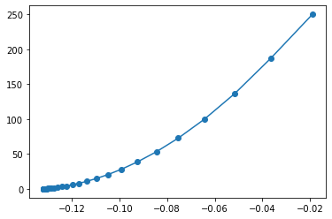

```python
plt.plot(dict2['optimum theta_0'],dict2['losses'],'-o')
```

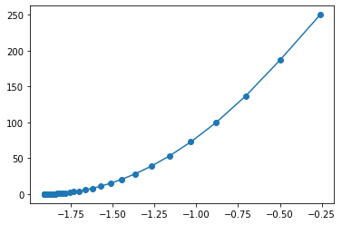

```python
plt.plot(dict2['optimum theta_1'],dict2['losses'],'-o')
```

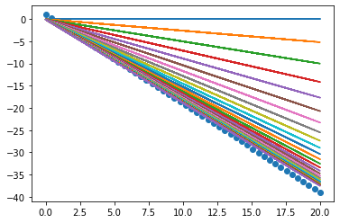

```python
plt.scatter(x,y)
for i in range(25) :
    plt.plot(x,dict2['hypothesis output'][i])
```

### Update your Batch GD for one variable implementation to be Momentum-Based GD and check your results

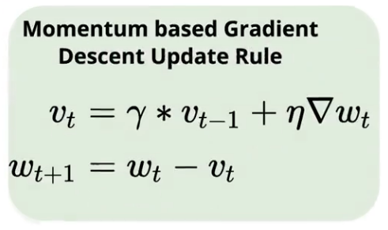

#### γ takes values between 0 and 1.

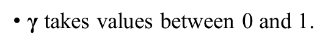

```python
def momentum_GD(x,y,alpha,epochs,gama):
    theta_0=[]
    theta_1=[]
    ress=[]
    theta0=0
    theta1=0
    hyp=[]
    v0=0
    v1=0
    v_0=[]
    v_1=[]

    for i in range(epochs):
        h=theta0+theta1*x
        hyp.append(h)
        error = sum((h-y)**2)
        res = error/ (2 * len(x))
        ress.append(res)
        a = sum(h-y) / ( len(x))
        b = sum((h-y)*x) / ( len(x))

        v0=gama*v0+ (alpha*a)
        v_0.append(v0)
        theta0 = theta0 - v0
        theta_0.append(theta0)
        v1=gama*v1+ (alpha*b)
        theta1 = theta1 - v1
        theta_1.append(theta1)
        v_1.append(v1)
        if i>0 and abs(ress[-1]-ress[-2])< 0.001 :
            break
    dict1={"theta_0":theta0,"theta_1":theta1,"losses":ress,"hypothesis output":hyp,"optimum theta_0":theta_0,"optimum theta_1":theta_1}
    return dict1
```

```python
dict3= momentum_GD(x,y,0.0001,100,0.9)
```

```python
h=theta0+theta1*x
```

```python
from sklearn.metrics import r2_score
r2_score(y, dict3["hypothesis output"][-1] )
```

```
0.9976473310594179
```

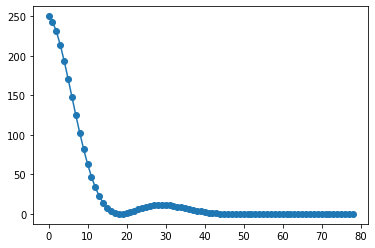

```python
plt.plot(dict3['losses'],'-o')
```

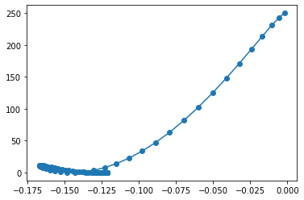

```python
plt.plot(dict3['optimum theta_0'],dict3['losses'],'-o')
```

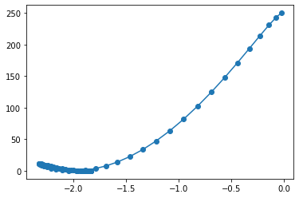

```python
plt.plot(dict3['optimum theta_1'],dict3['losses'],'-o')
```

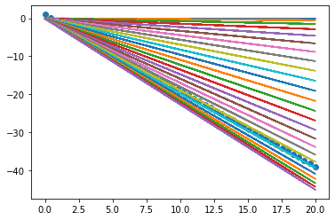

```python
plt.scatter(x,y)
for i in range(25) :
    plt.plot(x,dict3['hypothesis output'][i])
```

#### Try another values of momentum term and check your reults.

#### Try very large values close to one and very small values close to zero.

#### Try momentum = 0

```python
dict4= momentum_GD(x,y,0.0001,100,0)
```

```python
h=theta0+theta1*x
```

```python
from sklearn.metrics import r2_score
r2_score(y, dict4["hypothesis output"][-1] )
```

```
0.7557218991629473
```

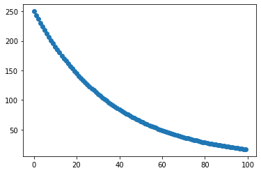

```python
plt.plot(dict4['losses'],'-o')
```

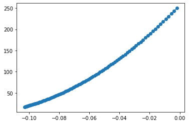

```python
plt.plot(dict4['optimum theta_0'],dict4['losses'],'-o')
```

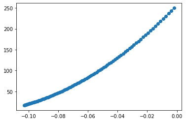

```python
plt.plot(dict4['optimum theta_0'],dict4['losses'],'-o')
```

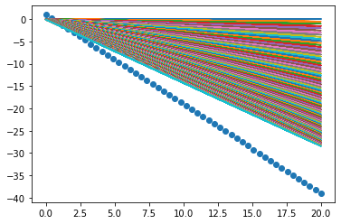

```python
plt.scatter(x,y)
for i in range(100) :
    plt.plot(x,dict4['hypothesis output'][i])
```

### Update your Batch GD for one variable implementation to be NAG and check your results

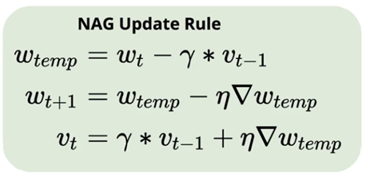

```python
def NAG_GD(x,y,alpha,epochs,gama):
    theta_0=[]
    theta_1=[]
    ress=[]
    loss=[]
    theta0=0
    theta0temp=0
    theta1=0
    theta1temp=0
    hyp=[]
    hyt=[]
    v0=0
    v1=0
    v_0=[]
    v_1=[]
    v_0_temp=[]
    v_1_temp=[]
    v0t=0
    v1t=0
    theta1_temp=[]
    theta0_temp=[]
    for i in range(epochs):
        h=theta0+theta1*x
        hyp.append(h)

        htemp=theta0temp+theta1temp*x
        hyt.append(htemp)

        error = sum((h-y)**2)
        res = error/ (2 * len(x))
        ress.append(res)

        error1 = sum((htemp-y)**2)
        les = error1/ (2 * len(x))
        loss.append(les)

        a = sum(h-y) / ( len(x))
        b = sum((h-y)*x) / ( len(x))

        atemp = sum(htemp-y) / ( len(x))
        btemp = sum((htemp-y)*x) / ( len(x))

        v0=gama*v0+ (alpha*a)

        v0t=gama*v0+ (alpha*atemp)

        v_0_temp.append(v0t)
        v_0.append(v0)


        theta0temp = theta0 - gama*v0
        theta0_temp.append(theta0temp)

        theta0 = theta0temp - alpha *atemp
        theta_0.append(theta0)

        v1=gama*v1+ (alpha*b)
        v1t=gama*v1+ (alpha*btemp)
        v_1_temp.append(v1t)

        theta1temp = theta1 - gama*v1
        theta1_temp.append(theta1temp)


        theta1 = theta1temp - alpha *atemp
        theta_1.append(theta1)

        v_1.append(v1)
        if i>0 and abs(ress[-1]-ress[-2])< 0.001 :
            break
    dict1={"theta_0":theta0,"theta_1":theta1, "theta0temp" : theta0temp , "theta1temp":theta1temp , "losses":ress ,"losstemp":loss ,"hypothesis output":hyp, "htemp":htemp,"optimum theta_0":theta_0,"optimum theta_1":theta_1,"theta0temp":theta0_temp,"theta1temp":theta0_temp}
    return dict1
```

```python
dict5 =NAG_GD(x,y,0.001,1000,.06)
```

```python
h=theta0+theta1*x
```

```python
from sklearn.metrics import r2_score
r2_score(y, dict5["hypothesis output"][-1] )
```

```
0.9913442681831497
```

```python
r2_score(y, dict5["htemp"] )
```

```
0.9913537336514558
```

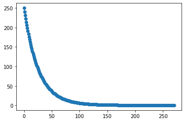

```python
plt.plot(dict5['losses'],'-o')
```

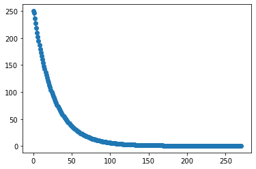

```python
plt.plot(dict5['losstemp'],'-o')
```

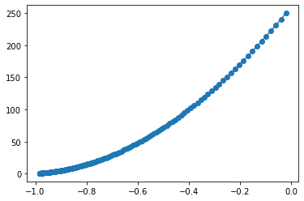

```python
plt.plot(dict5['optimum theta_0'],dict5['losses'],'-o')
```

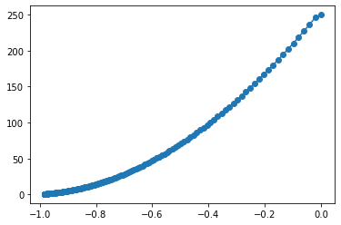

```python
plt.plot(dict5['theta0temp'],dict5['losstemp'],'-o')
```

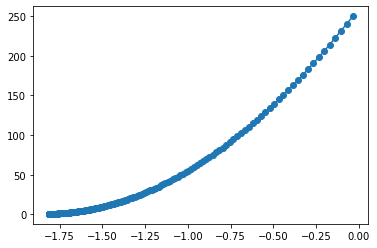

```python
plt.plot(dict5['optimum theta_1'],dict5['losses'],'-o')
```

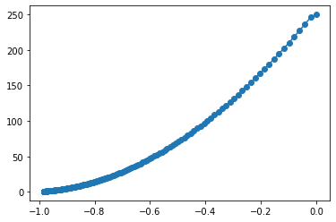

```python
plt.plot(dict5['theta1temp'],dict5['losstemp'],'-o')
```

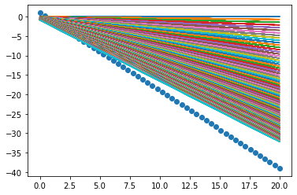

```python
plt.scatter(x,y)
for i in range(100) :
    plt.plot(x,dict5['hypothesis output'][i])
```

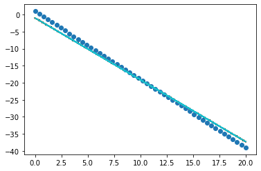

```python
plt.scatter(x,y)
for i in range(1000) :
    plt.plot(x,dict5['htemp'])
```

## Congratulations

[figure not shown]